# Naive Bayes para clasificacion

## 6. Haga un análisis de la eficiencia del modelo de clasificación usando una matriz de confusión. Tenga en cuenta la efectividad, donde el algoritmo se equivocó más, donde se equivocó menos y la importancia que tienen los errores.

```
## Confusion Matrix and Statistics
##
##           Reference
## Prediction barata estandar cara
##   barata      150       86   14
##   estandar      1       38   25
##   cara          0       18  107
##
## Overall Statistics
##
##                Accuracy : 0.672
##                  95% CI : (0.6259, 0.7158)
##     No Information Rate : 0.344
##     P-Value [Acc > NIR] : < 2.2e-16
##
##                   Kappa : 0.5047
##
##  Mcnemar's Test P-Value : < 2.2e-16
##
## Statistics by Class:
##
##                      Class: barata Class: estandar Class: cara
## Sensitivity                 0.9934         0.26761      0.7329
## Specificity                 0.6528         0.91246      0.9386
## Pos Pred Value              0.6000         0.59375      0.8560
## Neg Pred Value              0.9947         0.72267      0.8758
## Prevalence                  0.3440         0.32346      0.3326
## Detection Rate              0.3417         0.08656      0.2437
## Detection Prevalence        0.5695         0.14579      0.2847
## Balanced Accuracy           0.8231         0.59003      0.8357
```

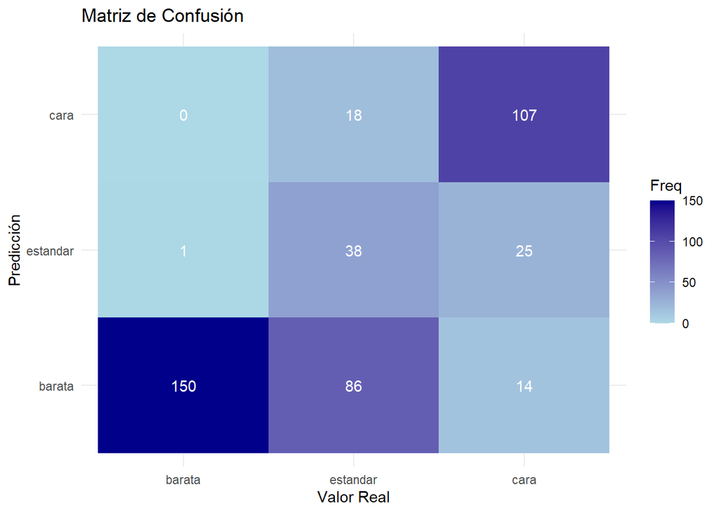

La matríz al final nos confirma el análisis realizado en el inciso anterior, realmente la clasificación con más problemas es la estándar. Pero ahora con la matríz podemos ver como es que esta clasificación se está realizando. Resulta que la clase estándar por lo general se clasifica de manera erronea como barata. Realmente fueron pocas las casas estándar que fueron calificadas como caras. Viendo la diagonal, en este caso de esquina inferior izquierda a esquna superior derecha por la posición de los labels en el gráfico, realmente la clasificación de casas baratas y caras fueron bastante exitosas y tienen un error pequeño. El color azul fuerte junto con el número nos lo confirma (agregado a las métricas analizidas anteriormente). La matriz es muy importante para analizar errores de manera visual y conocer específicamente en que parte es que el modelo falló y como falló. Ahora lo que corresponde es mejorar el módelo ajustando variables, eliminando variables o bien tuneando hiperparámetros para mejorar el desempeño.